# Assignment 1: Data Set Selection and Initial Processing

Luke Zhang

Note: many code chunks were adapted from Prof. Isserlin’s BCB420 lectures (especially low-count filtering, plotting, group definition, etc) and Dr. Boris Steipe’s online BCH441 modules (particularly package setup and data download).

## Download the Data Set

I chose GEO dataset GSE110021 for this assignment. First, install the required packages to download off of GEO.

```r
if (! requireNamespace("BiocManager", quietly = TRUE)) {
    install.packages("BiocManager")
}
if (! requireNamespace("GEOquery", quietly = TRUE)) {
    BiocManager::install("GEOquery")
}
```

Now download the supplementary file (only if it has not been downloaded already):

```r
datafile <- "GSE110021_counts.Aug2015.txt.gz"
if (!file.exists(datafile)) {
    files <- GEOquery::getGEOSuppFiles("GSE110021", makeDirectory = FALSE)
}
data <- read.delim(datafile,header=TRUE,check.names=FALSE)
dim(data)
```

```
## [1] 25702    48
```

```r
data[1:10,1:4]
```

```
##           D1.noTGFb.1_S1_L001 D1.noTGFb.1_S1_L002 D1.noTGFb.1_S1_L003
## 653635                     13                   9                  14
## 100422834                   0                   0                   0
## 645520                      0                   0                   0
## 79501                       0                   0                   0
## 729737                      1                   0                   0
## 100507658                   0                   0                   0
## 100132287                   1                   1                   0
## 100288646                   0                   0                   0
## 729759                      0                   0                   0
## 100131754                   2                   1                   3
##           D1.noTGFb.1_S1_L004
## 653635                     15
## 100422834                   0
## 645520                      0
## 79501                       0
## 729737                      0
## 100507658                   0
## 100132287                   0
## 100288646                   0
## 729759                      0
## 100131754                   8
```

We see that we have reads of 25702 genes across 48 columns. Each set of 4 columns corresponds to 1 sample (4 lanes on the sequencing machine). Thus we have 12 samples: size of replicate groups is 3, with 1-day and 20-day timeframes with and without treatment by TGFb.

## Initial Assessment

First let’s recover the sample counts by merging the individual lane counts:

```r
# build a new data.frame via a list to contain 1 column every group of 4 lanes
new_data <- list()
for (i in 0:11) {
    new_data <- c(new_data, list(rowSums(data[,(i+1):(4*(i+1))])))
}
new_data <- as.data.frame(new_data)
rownames(new_data) <- rownames(data)

# data colnames format:
# <dayNum>.<treatment>.<replicateNum>_<sampleNum>_<laneNum>
for (i in 1:12) {
    colnames(new_data)[i] <- unlist(strsplit(colnames(data[i*4]), "_"))[1]
}
new_data[1:10,1:6]
```

```
##           D1.noTGFb.1 D1.noTGFb.2 D1.noTGFb.3 D1.TGFb.1 D1.TGFb.2 D1.TGFb.3
## 653635             51         104         137       152       189       208
## 100422834           0           0           0         0         0         0
## 645520              0           0           0         0         0         0
## 79501               0           0           0         0         0         0
## 729737              1           2           3         4         6         6
## 100507658           0           0           0         0         0         0
## 100132287           2           1           0         0         0         0
## 100288646           0           0           0         0         0         0
## 729759              0           0           0         0         0         0
## 100131754          14          25          38        46        57        64
```

```r
rownames(new_data)[1:10]
```

```
##  [1] "653635"    "100422834" "645520"    "79501"     "729737"    "100507658"
##  [7] "100132287" "100288646" "729759"    "100131754"
```

Get a sense of our data distribution and quality by plotting the data for all noTGFb replicates on day 1 and day 20, as well as calculate some summary statistics:

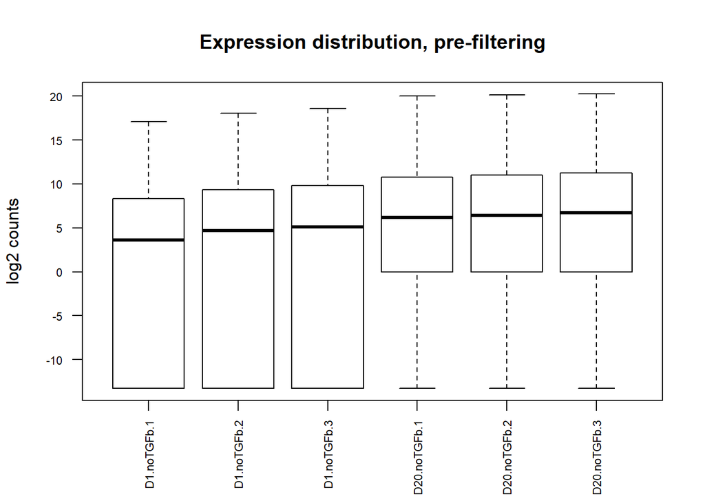

```r
dataToGraph <- cbind(new_data[,1:3], new_data[,7:9])
# add a pseudocount so log2 evaluates
boxplot(log2(dataToGraph + 0.0001), las = 2, ylab="log2 counts", main = "Expression distribution, pre-filtering", cex.axis=0.7)
```

```r
summary(log2(dataToGraph + 0.0001))
```

```
##   D1.noTGFb.1        D1.noTGFb.2       D1.noTGFb.3       D20.noTGFb.1
##  Min.   :-13.2877   Min.   :-13.288   Min.   :-13.288   Min.   :-13.287712
##  1st Qu.:-13.2877   1st Qu.:-13.288   1st Qu.:-13.288   1st Qu.:  0.000144
##  Median :  3.5850   Median :  4.700   Median :  5.087   Median :  6.169927
##  Mean   : -0.1578   Mean   :  1.076   Mean   :  1.535   Mean   :  2.777212
##  3rd Qu.:  8.3083   3rd Qu.:  9.347   3rd Qu.:  9.807   3rd Qu.: 10.793603
##  Max.   : 17.0901   Max.   : 18.070   Max.   : 18.583   Max.   : 20.051287
##   D20.noTGFb.2         D20.noTGFb.3
##  Min.   :-13.287712   Min.   :-13.287712
##  1st Qu.:  0.000144   1st Qu.:  0.000144
##  Median :  6.409393   Median :  6.707344
##  Mean   :  3.057301   Mean   :  3.368819
##  3rd Qu.: 10.996474   3rd Qu.: 11.231221
##  Max.   : 20.127328   Max.   : 20.237614
```

```r
length(unique(rownames(new_data))) == nrow(new_data)
```

```
## [1] TRUE
```

The last line of code returns TRUE, which demonstrates that all IDs listed as rownames in the given data are unique. This means that we do not have duplicate expression values for genes in the data.

The significant change we observe in this boxplot from day 1 to day 20 is hopefully indicative of good data with significant differential expression. Let’s also define the 4 groups of interest within our data:

```r
# 4 groups:
# 1. no TGFb, day 1
# 2. no TGFb, day 20
# 3. with TGFb, day 1
# 4. with TGFb, day 20
samples <- data.frame(lapply(colnames(new_data), FUN=function(x){unlist(strsplit(x,"\\."))[c(1,2)]}))
rownames(samples) <- c("Day", "Treatment")
colnames(samples) <- colnames(new_data)
samples <- data.frame(t(samples))
samples
```

```
##              Day Treatment
## D1.noTGFb.1   D1    noTGFb
## D1.noTGFb.2   D1    noTGFb
## D1.noTGFb.3   D1    noTGFb
## D1.TGFb.1     D1      TGFb
## D1.TGFb.2     D1      TGFb
## D1.TGFb.3     D1      TGFb
## D20.noTGFb.1 D20    noTGFb
## D20.noTGFb.2 D20    noTGFb
## D20.noTGFb.3 D20    noTGFb
## D20.TGFb.1   D20      TGFb
## D20.TGFb.2   D20      TGFb
## D20.TGFb.3   D20      TGFb
```

```r
rownames(samples)
```

```
##  [1] "D1.noTGFb.1"  "D1.noTGFb.2"  "D1.noTGFb.3"  "D1.TGFb.1"    "D1.TGFb.2"
##  [6] "D1.TGFb.3"    "D20.noTGFb.1" "D20.noTGFb.2" "D20.noTGFb.3" "D20.TGFb.1"
## [11] "D20.TGFb.2"   "D20.TGFb.3"
```

## Cleaning the Data

We use edgeR to remove uninformative and/or lowly expressed genes by filtering out all reads whose counts are too low.

```r
if (! requireNamespace("edgeR", quietly = TRUE)) {
    BiocManager::install("edgeR")
}
if (! requireNamespace("limma", quietly = TRUE)) {
    BiocManager::install("limma")
}
```

```r
cpm_data <- edgeR::cpm(new_data)
rownames(cpm_data) <- rownames(new_data)

filtered_data <- new_data[rowSums(cpm_data >= 1) >= 3, ]

dim(filtered_data)
```

```
## [1] 13259    12
```

We were able to filter out…

```r
length(data[,1]) - length(filtered_data[,1])
```

```
## [1] 12443
```

…12443 uninformative features.

## Data Normalization

Now that we’ve filtered out low counts, let’s see what the distributions for all our samples look like:

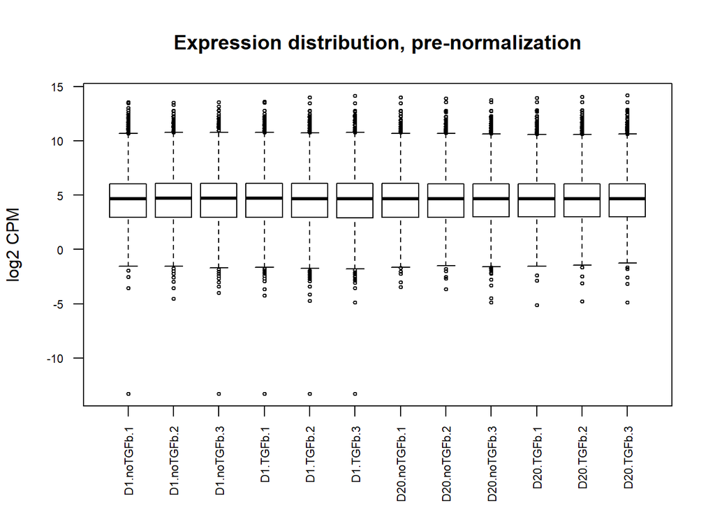

```r
boxplot(log2(edgeR::cpm(filtered_data) + 0.0001), ylab = "log2 CPM", main = "Expression distribution, pre-normalization", cex = 0.5, cex.axis=0.7, las=2)
```

The boxplot shows 5 sets of outliers (1 each for 5 of 6 D1 samples). These are 0 counts that I recovered by adding the pseudocount of 0.0001 to my data so log2 doesn’t throw an error warning. Let’s see how many of these outliers are there:

```r
idx <- 1:6
zeroes <- vector(length=6)

# Count number of 0s in each column.
# aka determine number of 0-counts for D1 samples.
for (i in idx) {
    zero_idx <- which(filtered_data[, i] == 0)
    zeroes[i] <- length(filtered_data[zero_idx,i])
}
zeroes
```

```
## [1] 3 0 1 1 1 1
```

Each element of this vector is the number of zero counts for each of the D1 samples. We see that they total to 7 outliers. Setting the limits to exclude these outliers:

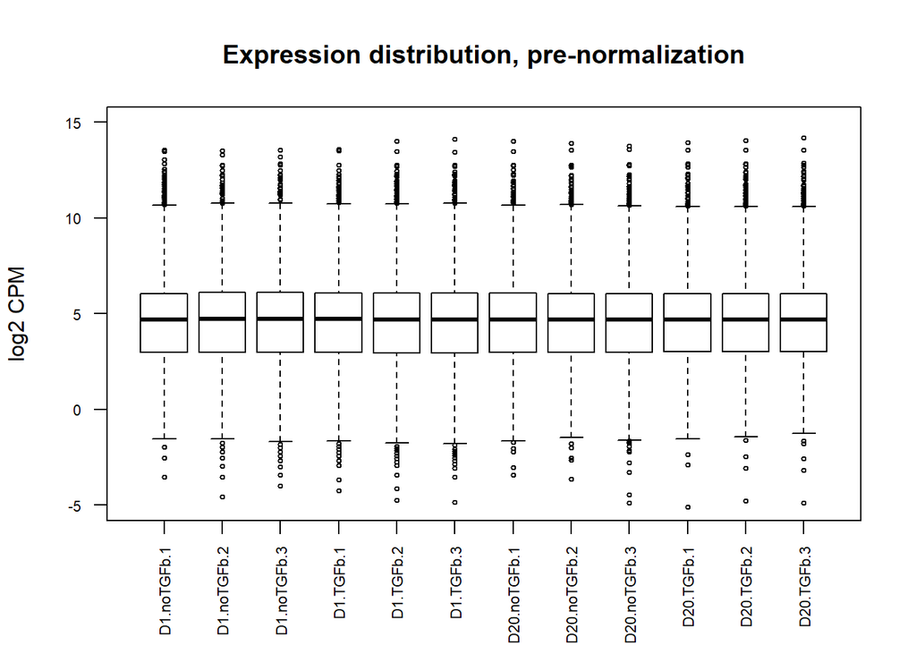

```r
boxplot(log2(edgeR::cpm(filtered_data) + 0.0001), ylab = "log2 CPM", main = "Expression distribution, pre-normalization", cex = 0.5, cex.axis=0.7, las=2, ylim=c(-5,15))
```

Normalize the data with edgeR TMM:

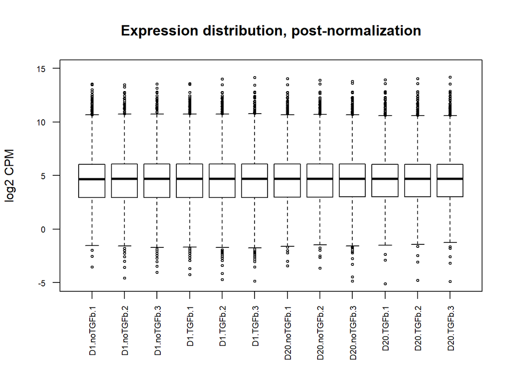

```r
filtered_matrix <- as.matrix(filtered_data)

# Normalize with respect to treatment type
d <- edgeR::DGEList(counts=filtered_matrix, group=samples$Treatment)
d <- edgeR::calcNormFactors(d)

norm_data <- edgeR::cpm(d)

boxplot(log2(norm_data + 0.0001), ylab = "log2 CPM", main= "Expression distribution, post-normalization", cex = 0.5, cex.axis=0.7, las=2, ylim=c(-5,15))
```

Use an MDS plot to represent how well the normalized samples are distinguished. The first plot is before normalization, and the second plot is after normalization.

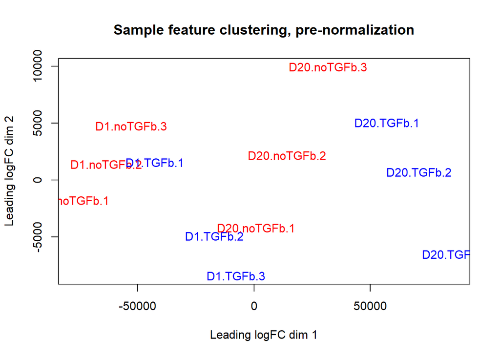

```r
limma::plotMDS(filtered_data, labels=rownames(samples), col=c("red","blue")[factor(samples$Treatment)], main="Sample feature clustering, pre-normalization")
```

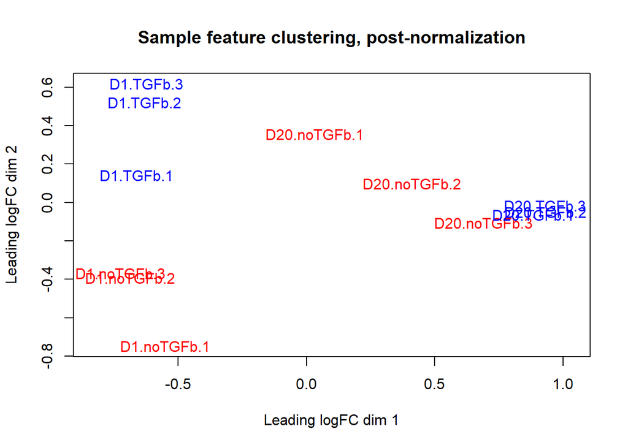

```r
limma::plotMDS(d, labels=rownames(samples), col=c("red","blue")[factor(samples$Treatment)], main="Sample feature clustering, post-normalization")
```

We see much clearer separation between different treatment groups (D1 vs D20, TGFb vs noTGFb), as well as tighter clustering between replicates of the same treatment group. This is a good outcome and means our normalization was effective.

## Mapping to HUGO Symbols

Supplementary file reveals that the rownames in the data are Entrez Gene IDs. We must map from Entrez IDs to HUGO symbols. For this we need the org.Hs.eg.db package and its functions.

```r
if (! requireNamespace("org.Hs.eg.db", quietly = TRUE)) {
    BiocManager::install("org.Hs.eg.db")
}
if (! requireNamespace("annotate", quietly = TRUE)) {
    BiocManager::install("annotate")
}
library(org.Hs.eg.db)
```

```r
# Map from Entrez Gene IDs to HUGO symbols
symbols <- annotate::lookUp(rownames(filtered_data), "org.Hs.eg", "SYMBOL")

# Remove all unmapped rows
mapped_indices <- which(!is.na(symbols))
mapped_data <- filtered_data[mapped_indices, ]

# Set HUGO symbols as rownames of new dataframe
mapped_symbols <- symbols[!is.na(symbols)]
rownames(mapped_data) <- mapped_symbols

# Are all HUGO symbols remaining unique? This must return TRUE
nrow(mapped_data) == length(unique(mapped_symbols))
```

```
## [1] TRUE
```

```r
# Final gene coverage of dataset
dim(mapped_data)
```

```
## [1] 12914    12
```

```r
# Number of rows deleted during mapping?
nrow(filtered_data) - nrow(mapped_data)
```

```
## [1] 345
```

mapped_data is the final output dataset of this workflow.

## Interpretation

*What are the control and test conditions of the dataset?*

The experiment consists of treating WI-38 fibroblasts with TGFb (transforming growth factor beta) and comparing the induced expression changes with a control group at both 1-day and 20-day time points. In this case, the experimental group would be the cells that are treated with TGFb, and the control group are the cells that received no treatment.

*Why is the dataset of interest to me?*

TGFb is known to trigger transdifferentiation of epithelial cells in the airway into mesenchymal cells, which is one of the ways that asthmatic symptoms arise. The dataset is from a study that examined the induced pathways by TGFb in search for genes that are up or downregulated in the downstream fibroblast pathways. These are all candidate genes that contribute to asthma, which is a common chronic lung disease that I and many relatives personally have. I thought it would be interesting to examine these pathways myself.

*Were there expression values that were not unique for specific genes? How did you handle them?*

No. A quick test demonstrated that there are no repeated identifiers, even before the mapping to HUGO. I simply proceeded with the rest of the workflow as normal.

*Were there expression values that could not be mapped to current HUGO symbols?*

Yes, there were. 345 expression values were unable to be mapped to HUGO symbols, evident by the number of NA values I removed after conducting the mapping.

*How many outliers were removed?*

I noticed 7 outliers in my data (the sets of zero-counts in 5 out of 6 D1 samples). I didn’t remove any because I felt that their presence was too consistent across one group to simply be measurement error. However, I did reframe the boxplots to exclude these leftover low counts to better see the rest of the data.

*How did you handle replicates?*

I split my data into 4 groups of 3. One group for each combination of time and treatment, and each group contains 3 replicates. I kept each replicate separate, but made sure that replicates of two different groups are clearly differentiated in their names. Finally, I used n = 3 as the low-count threshold for filtering uninformative features, as per edgeR recommendation.

*What is the final coverage of your dataset?*

The final coverage of my dataset is 12914 features across 12 samples.

Summarizing dimensions of data across entire workflow:

```r
summary <- list(initial=dim(data), merged_lanes=dim(new_data), removed_low_counts=dim(filtered_data), mapped=dim(mapped_data))
summary
```

```
## $initial
## [1] 25702    48
##
## $merged_lanes
## [1] 25702    12
##
## $removed_low_counts
## [1] 13259    12
##
## $mapped
## [1] 12914    12
```